# Phân tích Thống kê Đa chiều (PCA, EFA, GMM, Multiple Regression)

Nhóm Đồ án

2026-07-05

# Phần 3: Dự báo Suy thoái Động cơ Máy bay C-MAPSS (PCA, EFA, GMM, MULTIPLE REGRESSION)

**DATASET**: C-MAPSS FD001 (Run-to-Failure)

## Cài đặt các gói cần thiết

```r
# install.packages(c("tidyverse", "psych", "mclust", "corrplot", "Metrics", "zoo", "factoextra", "reshape2", "MVN"))
```

```r
library(tidyverse)
library(psych)
library(mclust)
library(corrplot)
library(Metrics)
library(zoo)
library(factoextra)
library(reshape2)
library(MASS)  # Phân tích Biệt thức (LDA/QDA)
```

## 3.1 Khám phá Đặc trưng Cơ học (EDA)

### 3.1.1 Đọc Dữ liệu Train và Test

Bộ dữ liệu C-MAPSS cung cấp tập `cmapss_train_FD001.txt` và `cmapss_test_FD001.txt`. Để đánh giá độ chính xác của dự báo (RMSE) một cách công bằng nhất, ta phải huấn luyện mô hình trên tập Train và kiểm tra sai số trên tập Test.

```r
train_path <- "CMAPSSData/cmapss_train_FD001.txt"
test_path  <- "CMAPSSData/cmapss_test_FD001.txt"
rul_path   <- "CMAPSSData/RUL_FD001.txt"

df_train <- read.table(train_path, header = FALSE)
df_test  <- read.table(test_path, header = FALSE)
true_rul <- read.table(rul_path, header = FALSE)

colnames_df <- c("engine_id", "cycle", "op1", "op2", "op3", paste0("S", 1:21))
colnames(df_train) <- colnames_df
colnames(df_test)  <- colnames_df

# Chọn 14 biến cảm biến có ích (bỏ các biến tĩnh)
useful_sensors <- c("S2", "S3", "S4", "S7", "S8", "S9", "S11",
                    "S12", "S13", "S14", "S15", "S17", "S20", "S21")
df_train <- df_train[, c("engine_id", "cycle", useful_sensors)]
df_test  <- df_test[, c("engine_id", "cycle", useful_sensors)]

# Tính RUL cho tập Train
df_train <- df_train %>%
  group_by(engine_id) %>%
  mutate(RUL = max(cycle) - cycle,
         RUL = ifelse(RUL > 125, 125, RUL)) %>%
  ungroup()
```

Trực quan hóa đường cong RUL (Piecewise Linear Degradation) của động cơ số 1 để thấy rõ việc cắt trần ở 125 chu kỳ:

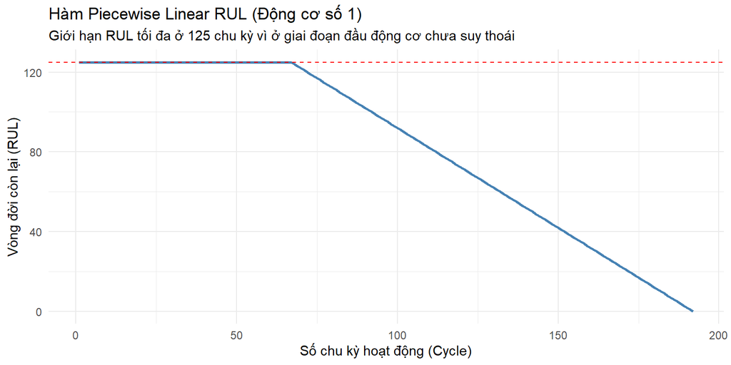

```r
ggplot(df_train %>% filter(engine_id == 1), aes(x = cycle, y = RUL)) +
  geom_line(color = "steelblue", size = 1) +
  geom_hline(yintercept = 125, linetype = "dashed", color = "red") +
  theme_minimal() +
  labs(title = "Hàm Piecewise Linear RUL (Động cơ số 1)",
       subtitle = "Giới hạn RUL tối đa ở 125 chu kỳ vì ở giai đoạn đầu động cơ chưa suy thoái",
       x = "Số chu kỳ hoạt động (Cycle)",
       y = "Vòng đời còn lại (RUL)")
```

### 3.1.2 Tổng quan Dữ liệu

```r
summary(df_train[, useful_sensors])
```

```
##        S2              S3             S4             S7              S8
##  Min.   :641.2   Min.   :1571   Min.   :1382   Min.   :549.9   Min.   :2388
##  1st Qu.:642.3   1st Qu.:1586   1st Qu.:1402   1st Qu.:552.8   1st Qu.:2388
##  Median :642.6   Median :1590   Median :1408   Median :553.4   Median :2388
##  Mean   :642.7   Mean   :1591   Mean   :1409   Mean   :553.4   Mean   :2388
##  3rd Qu.:643.0   3rd Qu.:1594   3rd Qu.:1415   3rd Qu.:554.0   3rd Qu.:2388
##  Max.   :644.5   Max.   :1617   Max.   :1441   Max.   :556.1   Max.   :2389
##        S9            S11             S12             S13            S14
##  Min.   :9022   Min.   :46.85   Min.   :518.7   Min.   :2388   Min.   :8100
##  1st Qu.:9053   1st Qu.:47.35   1st Qu.:521.0   1st Qu.:2388   1st Qu.:8133
##  Median :9061   Median :47.51   Median :521.5   Median :2388   Median :8141
##  Mean   :9065   Mean   :47.54   Mean   :521.4   Mean   :2388   Mean   :8144
##  3rd Qu.:9069   3rd Qu.:47.70   3rd Qu.:522.0   3rd Qu.:2388   3rd Qu.:8148
##  Max.   :9245   Max.   :48.53   Max.   :523.4   Max.   :2389   Max.   :8294
##       S15             S17             S20             S21
##  Min.   :8.325   Min.   :388.0   Min.   :38.14   Min.   :22.89
##  1st Qu.:8.415   1st Qu.:392.0   1st Qu.:38.70   1st Qu.:23.22
##  Median :8.439   Median :393.0   Median :38.83   Median :23.30
##  Mean   :8.442   Mean   :393.2   Mean   :38.82   Mean   :23.29
##  3rd Qu.:8.466   3rd Qu.:394.0   3rd Qu.:38.95   3rd Qu.:23.37
##  Max.   :8.585   Max.   :400.0   Max.   :39.43   Max.   :23.62
```

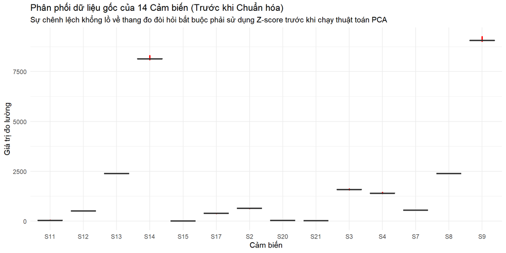

```r
df_train %>%
  dplyr::select(all_of(useful_sensors)) %>%
  pivot_longer(cols = everything(), names_to = "Sensor", values_to = "Value") %>%
  ggplot(aes(x = Sensor, y = Value, fill = Sensor)) +
  geom_boxplot(outlier.size = 0.5, outlier.color = "red", alpha = 0.7) +
  theme_minimal() +
  labs(title = "Phân phối dữ liệu gốc của 14 Cảm biến (Trước khi Chuẩn hóa)",
       subtitle = "Sự chênh lệch khổng lồ về thang đo đòi hỏi bắt buộc phải sử dụng Z-score trước khi chạy thuật toán PCA",
       x = "Cảm biến",
       y = "Giá trị đo lường") +
  theme(legend.position = "none")
```

### 3.1.3 Tín hiệu thô của 4 cảm biến tiêu biểu

Trực quan hóa tín hiệu gốc cho thấy xu hướng suy thoái bị vùi lấp dưới lớp nhiễu tần số cao.

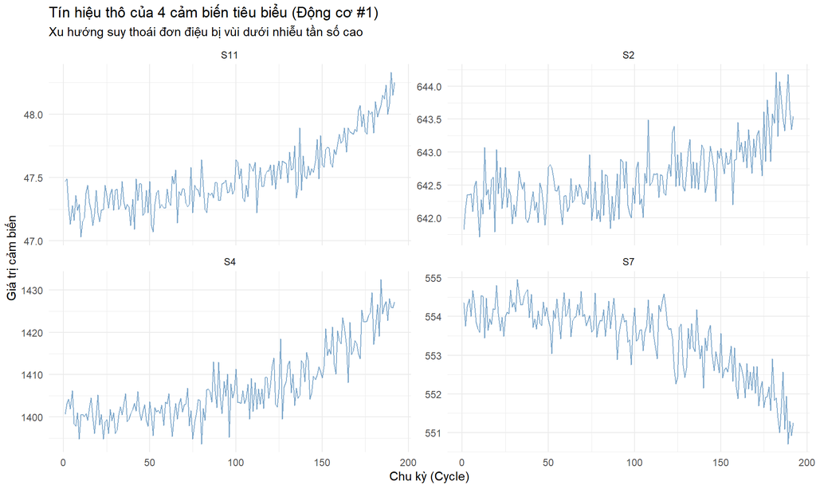

```r
df_engine1 <- df_train %>% filter(engine_id == 1)
df_raw_long <- df_engine1 %>%
  dplyr::select(cycle, S2, S4, S7, S11) %>%
  pivot_longer(-cycle, names_to = "Sensor", values_to = "Value")

ggplot(df_raw_long, aes(x = cycle, y = Value)) +
  geom_line(alpha = 0.7, color = "steelblue") +
  facet_wrap(~ Sensor, scales = "free_y", ncol = 2) +
  theme_minimal() +
  labs(title = "Tín hiệu thô của 4 cảm biến tiêu biểu (Động cơ #1)",
       subtitle = "Xu hướng suy thoái đơn điệu bị vùi dưới nhiễu tần số cao",
       x = "Chu kỳ (Cycle)", y = "Giá trị cảm biến")
```

### 3.1.4 Ma trận Tương quan (Correlation Matrix)

Phân tích tương quan cho thấy nhiều cảm biến có mức tương quan rất cao (Đa cộng tuyến), chứng tỏ dữ liệu phù hợp để nén chiều bằng PCA.

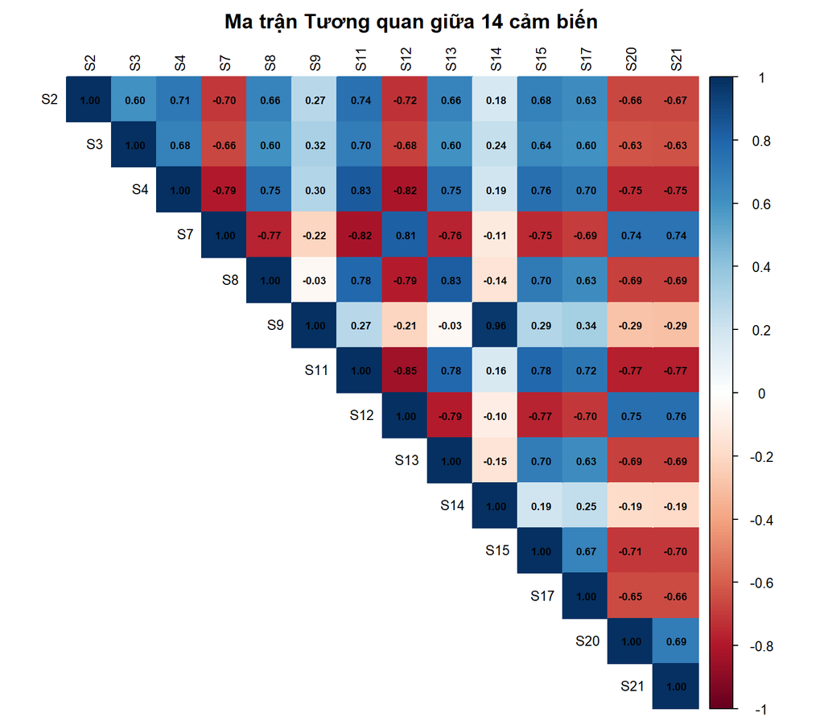

```r
cor_matrix_eda <- cor(df_train[, useful_sensors])
corrplot(cor_matrix_eda, method = "color", type = "upper",
         tl.cex = 0.8, tl.col = "black", addCoef.col = "black", number.cex = 0.6,
         title = "Ma trận Tương quan giữa 14 cảm biến",
         mar = c(0, 0, 2, 0))
```

## 3.2 Tiền xử lý Dữ liệu

### 3.2.1 Chuẩn hóa Min-Max & Boxplot

Vẽ Boxplot biểu diễn sự phân tán của 14 cảm biến (Sau khi chuẩn hóa Min-Max):

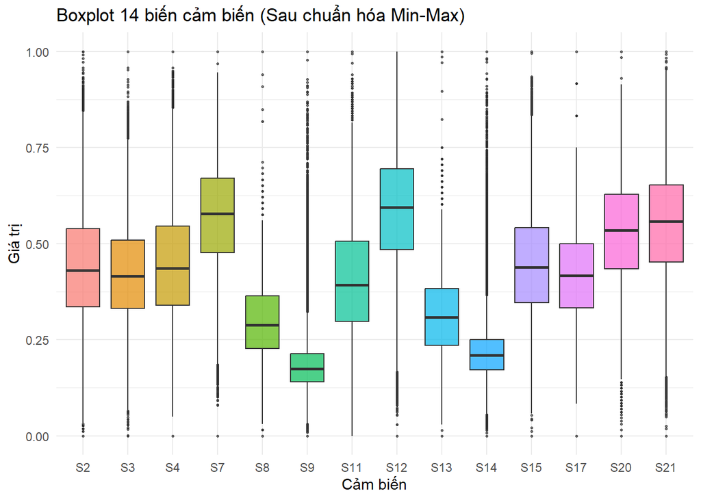

```r
train_min <- apply(df_train[, useful_sensors], 2, min)
train_max <- apply(df_train[, useful_sensors], 2, max)

scale_minmax <- function(data, min_vals, max_vals) {
  scaled <- scale(data, center = min_vals, scale = max_vals - min_vals)
  return(as.data.frame(scaled))
}

df_train[, useful_sensors] <- scale_minmax(df_train[, useful_sensors], train_min, train_max)
df_test[, useful_sensors]  <- scale_minmax(df_test[, useful_sensors], train_min, train_max)

# Vẽ Boxplot
df_melt <- melt(df_train[, useful_sensors])
ggplot(df_melt, aes(x=variable, y=value, fill=variable)) +
  geom_boxplot(alpha=0.7, outlier.size=0.5) +
  theme_minimal() +
  labs(title="Boxplot 14 biến cảm biến (Sau chuẩn hóa Min-Max)", x="Cảm biến", y="Giá trị") +
  theme(legend.position="none")
```

### 3.2.2 Lọc khử nhiễu (Moving Average và Kalman Filter)

Định nghĩa hàm lọc và áp dụng cho từng động cơ độc lập.

```r
# Hàm lọc Moving Average (cửa sổ w = 30) để thấy rõ độ trễ (lag)
apply_ma <- function(x, w=30) {
  res <- zoo::rollmean(x, k=w, fill=NA, align="right")
  res[is.na(res)] <- x[is.na(res)]
  return(res)
}

# Hàm lọc Kalman (1D cơ bản)
apply_kalman <- function(x) {
  n <- length(x)
  if (n == 0) return(x)
  xhat <- numeric(n)
  P <- numeric(n)
  Q <- 1e-4
  R <- 0.001 # Giảm nhiễu đo lường để bám sát thực tế hơn, tránh bị trễ pha
  xhat[1] <- x[1]
  P[1] <- 1.0
  for(k in 2:n) {
    x_minus <- xhat[k-1]
    P_minus <- P[k-1] + Q
    K <- P_minus / (P_minus + R)
    xhat[k] <- x_minus + K * (x[k] - x_minus)
    P[k] <- (1 - K) * P_minus
  }
  return(xhat)
}

# Lọc tập Train
df_train_ma <- df_train %>% group_by(engine_id) %>% mutate(across(starts_with("S"), apply_ma)) %>% ungroup()
df_train_kf <- df_train %>% group_by(engine_id) %>% mutate(across(starts_with("S"), apply_kalman)) %>% ungroup()

# Lọc tập Test
df_test_ma <- df_test %>% group_by(engine_id) %>% mutate(across(starts_with("S"), apply_ma)) %>% ungroup()
df_test_kf <- df_test %>% group_by(engine_id) %>% mutate(across(starts_with("S"), apply_kalman)) %>% ungroup()
```

### 3.2.3 So sánh trực quan: Raw vs Moving Average vs Kalman Filter

Minh họa lợi thế của Kalman Filter so với Moving Average trên cùng 1 cảm biến.

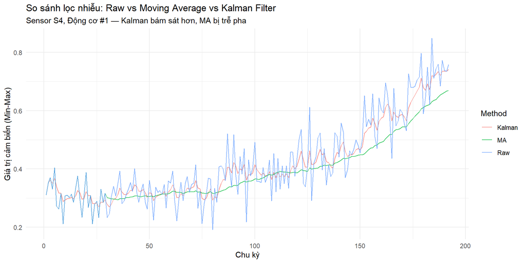

```r
df_compare <- data.frame(
  Cycle = df_train %>% filter(engine_id == 1) %>% pull(cycle),
  Raw    = df_train %>% filter(engine_id == 1) %>% pull(S4),
  MA     = df_train_ma %>% filter(engine_id == 1) %>% pull(S4),
  Kalman = df_train_kf %>% filter(engine_id == 1) %>% pull(S4)
) %>%
  pivot_longer(-Cycle, names_to = "Method", values_to = "Value")

ggplot(df_compare, aes(x = Cycle, y = Value, color = Method)) +
  geom_line(alpha = 0.8) +
  theme_minimal() +
  labs(title = "So sánh lọc nhiễu: Raw vs Moving Average vs Kalman Filter",
       subtitle = "Sensor S4, Động cơ #1 — Kalman bám sát hơn, MA bị trễ pha",
       x = "Chu kỳ", y = "Giá trị cảm biến (Min-Max)")
```

### 3.2.4 Kiểm định Phân phối Chuẩn Nhiều chiều (Multivariate Normality — Mardia’s Test)

PCA và GMM đều dựa trên giả định phân phối chuẩn. Sử dụng kiểm định Mardia (Skewness + Kurtosis đa chiều) từ gói `psych`.

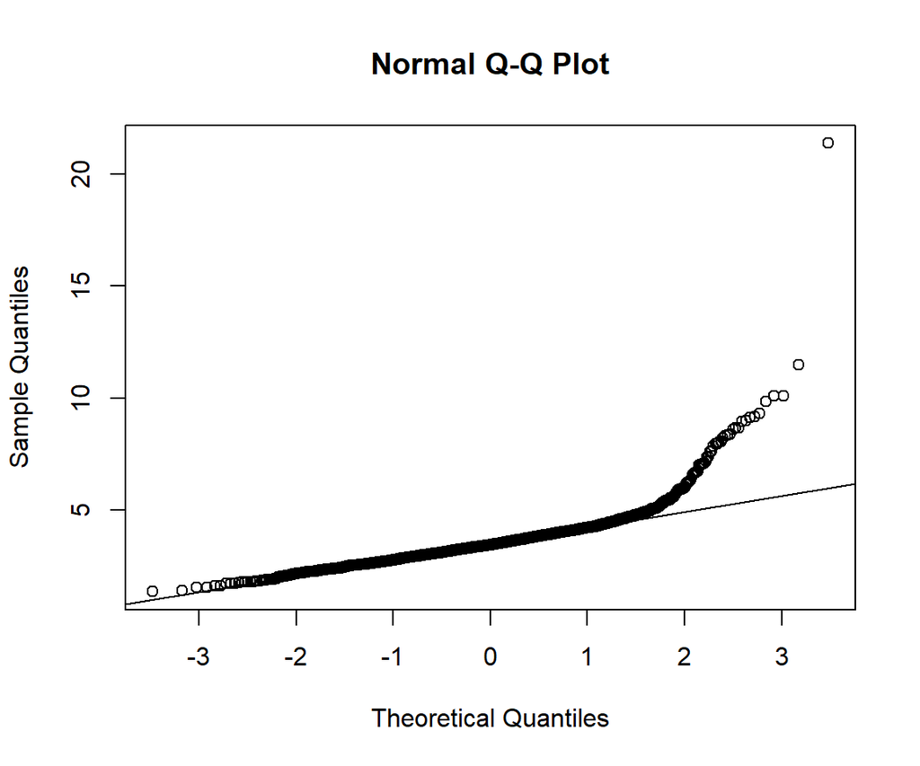

```r
# Lấy mẫu ngẫu nhiên 2000 dòng để tính toán nhanh hơn
set.seed(42)
df_mvn_sample <- df_train_kf[sample(nrow(df_train_kf), 2000), useful_sensors]

# Kiểm định Mardia (psych package) vẽ sẵn QQ-Plot
mardia_res <- mardia(df_mvn_sample)
```

```r
print(mardia_res)
```

```
## Call: mardia(x = df_mvn_sample)
##
## Mardia tests of multivariate skew and kurtosis
## Use describe(x) the to get univariate tests
## n.obs = 2000   num.vars =  14
## b1p =  47.77   skew =  15924.18  with probability  <=  0
##  small sample skew =  15951.26  with probability <=  0
## b2p =  383.39   kurtosis =  168.38  with probability <=  0
```

## 3.3 Kiểm định KMO, Bartlett và Parallel Analysis

### 3.3.1 Kiểm định KMO và Bartlett’s Test

Kiểm định trên tập Train để chứng minh sự hiện diện của “Đa cộng tuyến” và mức độ phù hợp của dữ liệu trước khi chạy PCA.

```r
cat("\n--- KIỂM ĐỊNH KMO & BARTLETT ---\n")
```

```
##
## --- KIỂM ĐỊNH KMO & BARTLETT ---
```

```r
cor_matrix <- cor(df_train[, useful_sensors])

bartlett_res <- cortest.bartlett(cor_matrix, n = nrow(df_train))
cat("Bartlett's Test p-value:", bartlett_res$p.value, "\n")
```

```
## Bartlett's Test p-value: 0
```

```r
kmo_res <- KMO(cor_matrix)
cat("KMO Overall:", kmo_res$MSA, "\n")
```

```
## KMO Overall: 0.960933
```

## 3.4 Phân tích Thành phần Chính (PCA)

Áp dụng PCA trên tập Train, sau đó dùng mô hình PCA đó để project (chuyển đổi) tập Test.

```r
cat("\n--- PHÂN TÍCH THÀNH PHẦN CHÍNH (PCA) ---\n")
```

```
##
## --- PHÂN TÍCH THÀNH PHẦN CHÍNH (PCA) ---
```

```r
pca_ma <- prcomp(df_train_ma[, useful_sensors], center = TRUE, scale. = TRUE)
pca_kf <- prcomp(df_train_kf[, useful_sensors], center = TRUE, scale. = TRUE)

df_train$PC1_MA <- pca_ma$x[, 1]
df_train$PC1_KF <- pca_kf$x[, 1]

# Căn chỉnh dấu PC1 sao cho tương quan thuận với RUL
if(cor(df_train$PC1_MA, df_train$RUL) < 0) { pca_ma$rotation <- -pca_ma$rotation; df_train$PC1_MA <- -df_train$PC1_MA }
if(cor(df_train$PC1_KF, df_train$RUL) < 0) { pca_kf$rotation <- -pca_kf$rotation; df_train$PC1_KF <- -df_train$PC1_KF }

# Transform tập Test sang không gian PC1
df_test$PC1_MA <- predict(pca_ma, newdata = df_test_ma[, useful_sensors])[, 1]
df_test$PC1_KF <- predict(pca_kf, newdata = df_test_kf[, useful_sensors])[, 1]
```

### 3.4.1 Trực quan hóa PCA (Screeplot, Biplot, Loadings)

Vẽ đồ thị Screeplot để xác định số lượng thành phần chính (PC) nên giữ lại.

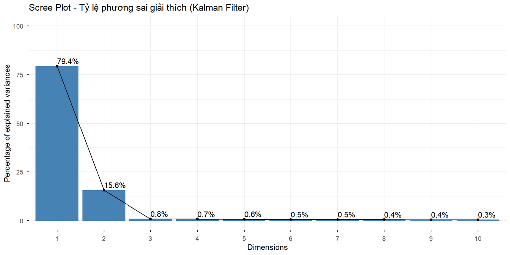

```r
# 1. Screeplot
fviz_eig(pca_kf, addlabels = TRUE, ylim = c(0, 100),
         title = "Scree Plot - Tỷ lệ phương sai giải thích (Kalman Filter)")
```

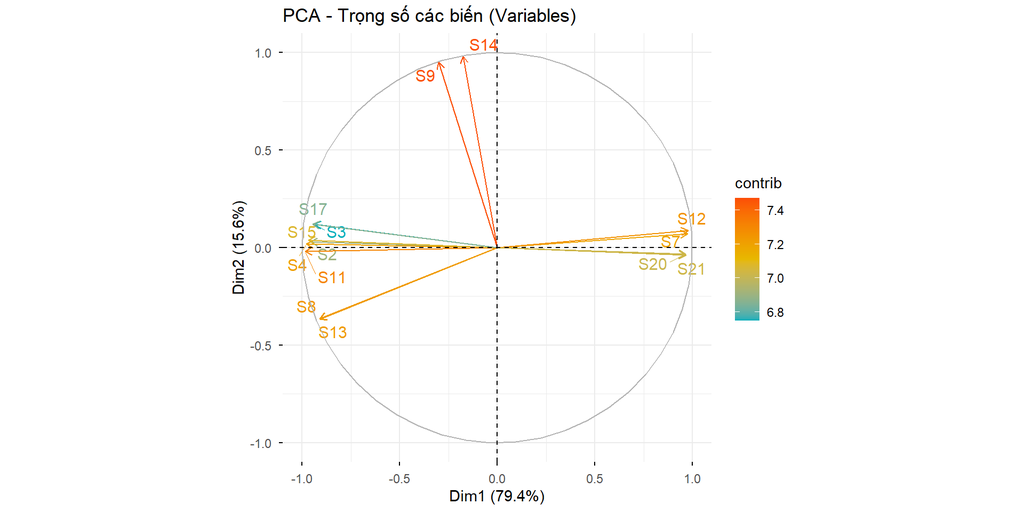

```r
# 2. Đồ thị biến (Variables plot)
fviz_pca_var(pca_kf,
             col.var = "contrib", # Màu sắc dựa trên mức độ đóng góp
             gradient.cols = c("#00AFBB", "#E7B800", "#FC4E07"),
             repel = TRUE,        # Tránh chữ đè lên nhau
             title = "PCA - Trọng số các biến (Variables)")
```

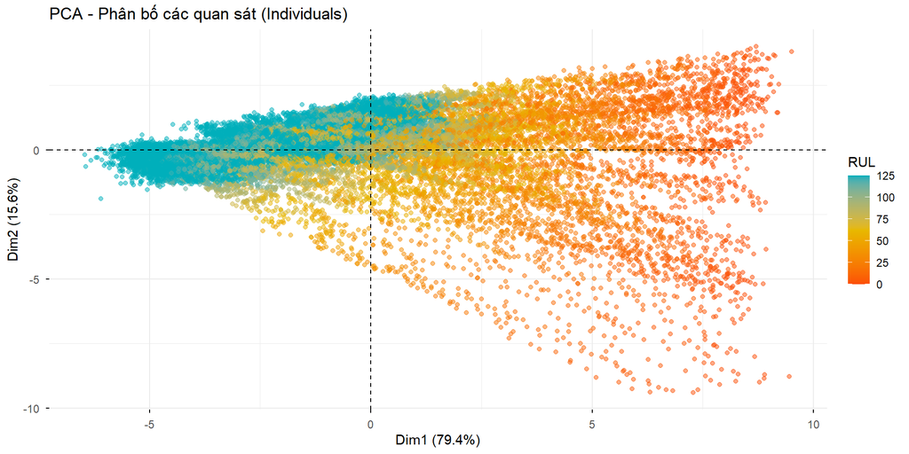

```r
# 3. Đồ thị các quan sát (Individuals plot)
# Tô màu các điểm (quan sát) theo vòng đời còn lại (RUL)
# Tránh lag do có >20,000 điểm nên chỉ dùng điểm, không dùng text (geom="point")
fviz_pca_ind(pca_kf,
             geom = "point",
             col.ind = df_train$RUL,
             gradient.cols = c("#FC4E07", "#E7B800", "#00AFBB"), # Đỏ (sắp hỏng) tới Xanh (còn tốt)
             alpha.ind = 0.5,
             legend.title = "RUL",
             title = "PCA - Phân bố các quan sát (Individuals)")
```

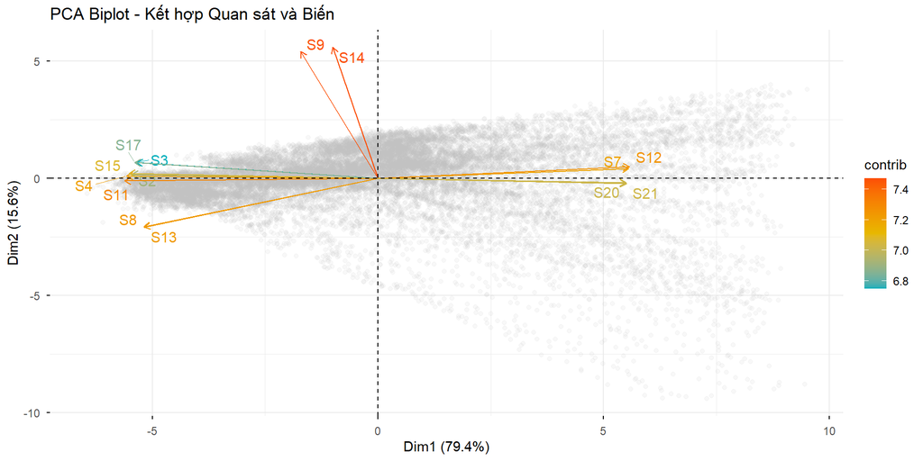

```r
# 4. Đồ thị Biplot kết hợp (Biplot)
fviz_pca_biplot(pca_kf,
                geom.ind = "point",
                col.ind = "gray",      # Điểm quan sát màu xám
                alpha.ind = 0.1,       # Mờ để nổi bật biến
                col.var = "contrib",   # Biến đổi màu theo độ đóng góp
                gradient.cols = c("#00AFBB", "#E7B800", "#FC4E07"),
                repel = TRUE,
                title = "PCA Biplot - Kết hợp Quan sát và Biến")
```

### 3.4.2 Parallel Analysis (Xác định số PC tối ưu bằng phương pháp thống kê) Parallel Analysis so sánh trị riêng thực với trị riêng giả (random) để xác định khách quan bao nhiêu PC nên giữ lại.

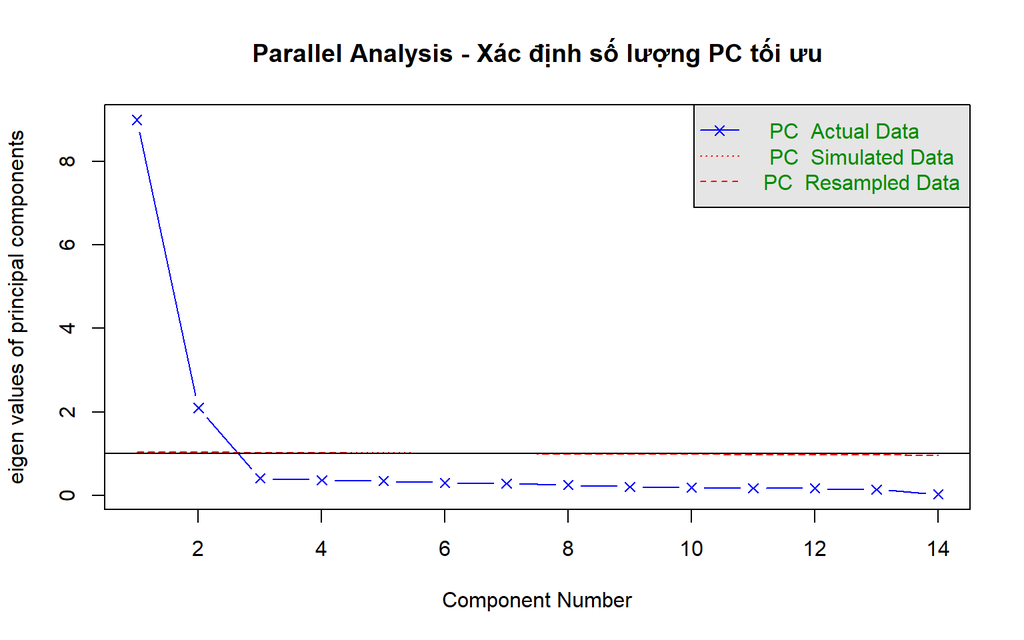

```
## Parallel analysis suggests that the number of factors =  NA  and the number of components =  2
```

```r
fa.parallel(df_train[, useful_sensors], fa = "pc", n.iter = 100,
            main = "Parallel Analysis - Xác định số lượng PC tối ưu")
```

### 3.4.3 Loadings Barplot (Trọng số của 3 Thành phần Chính)

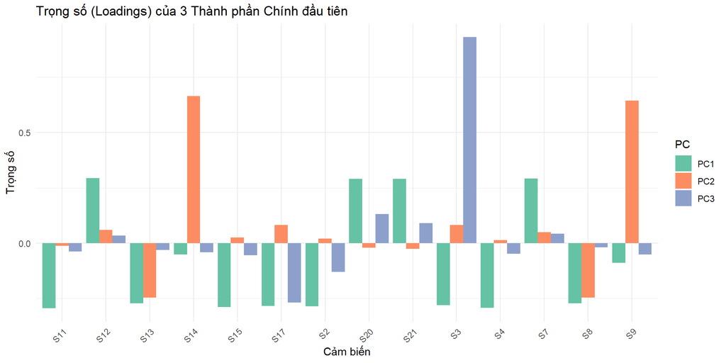

```r
loadings_df <- as.data.frame(pca_kf$rotation[, 1:3])
loadings_df$Sensor <- rownames(loadings_df)
loadings_long <- pivot_longer(loadings_df, -Sensor, names_to = "PC", values_to = "Loading")

ggplot(loadings_long, aes(x = Sensor, y = Loading, fill = PC)) +
  geom_bar(stat = "identity", position = "dodge") +
  theme_minimal() +
  labs(title = "Trọng số (Loadings) của 3 Thành phần Chính đầu tiên",
       x = "Cảm biến", y = "Trọng số") +
  theme(axis.text.x = element_text(angle = 45, hjust = 1)) +
  scale_fill_brewer(palette = "Set2")
```

## 3.5 Phân tích Quỹ đạo và Cảnh báo sớm (Mahalanobis Distance)

Trong thực tế, ta cần theo dõi xu hướng suy thoái của động cơ và phát hiện các dấu hiệu bất thường sớm. Trục PC1 sau khi lọc bằng Kalman Filter ($PC1\_KF$) đóng vai trò như một **Chỉ số Sức khỏe (Health Index)** liên tục.

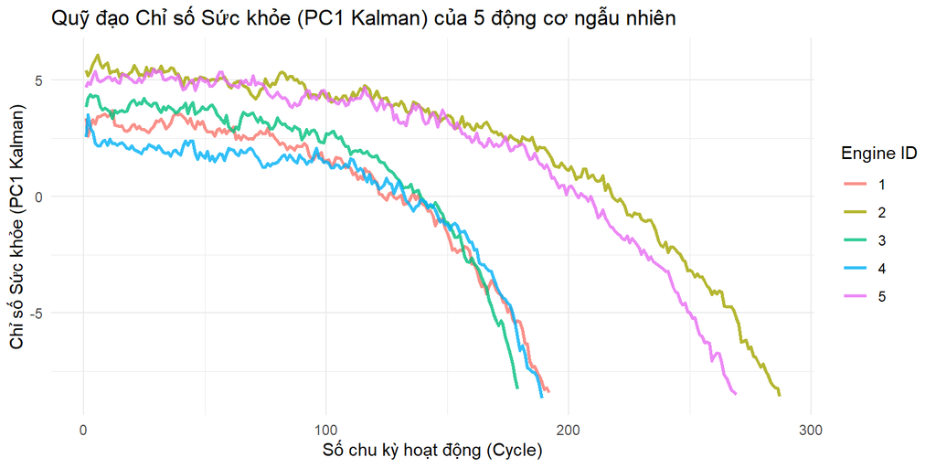

```r
df_5_engines <- df_train %>% filter(engine_id %in% 1:5)
ggplot(df_5_engines, aes(x = cycle, y = PC1_KF, color = as.factor(engine_id))) +
  geom_line(size = 1, alpha = 0.8) +
  theme_minimal() +
  labs(title = "Quỹ đạo Chỉ số Sức khỏe (PC1 Kalman) của 5 động cơ ngẫu nhiên",
       x = "Số chu kỳ hoạt động (Cycle)",
       y = "Chỉ số Sức khỏe (PC1 Kalman)",
       color = "Engine ID")
```

### 3.5.2 Đường cong Cảnh báo sớm dựa trên Khoảng cách Mahalanobis đa chiều

Bằng cách đo lường khoảng cách Mahalanobis $D_M$ của các quan sát hiện tại so với trạng thái khỏe mạnh (30 chu kỳ đầu), ta có thể kích hoạt cảnh báo khi hệ thống lệch khỏi quỹ đạo bình thường.

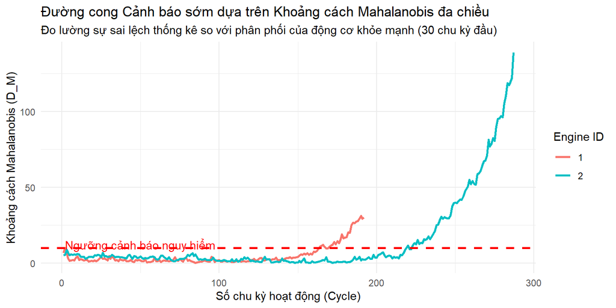

```r
# Trích xuất PC2, PC3 từ mô hình PCA để dùng cho Mahalanobis đa chiều
pca_proj <- predict(pca_kf, df_train_kf[, useful_sensors])
df_train$PC2 <- pca_proj[, 2]
df_train$PC3 <- pca_proj[, 3]

# Khởi tạo trạng thái "Khỏe mạnh" (Healthy state) là 30 chu kỳ đầu tiên của tất cả động cơ
healthy_data <- df_train %>% filter(cycle <= 30) %>% dplyr::select(PC1_KF, PC2, PC3)
healthy_mean <- colMeans(healthy_data)
healthy_cov <- cov(healthy_data)

# Tính khoảng cách Mahalanobis cho động cơ 1 và 2 để làm mẫu cảnh báo sớm
df_mhd <- df_train %>% filter(engine_id %in% 1:2)
df_mhd$Mahalanobis <- mahalanobis(df_mhd[, c("PC1_KF", "PC2", "PC3")], center = healthy_mean, cov = healthy_cov)

ggplot(df_mhd, aes(x = cycle, y = Mahalanobis, color = as.factor(engine_id))) +
  geom_line(size = 1) +
  geom_hline(yintercept = 10, linetype = "dashed", color = "red", size = 1) +
  theme_minimal() +
  labs(title = "Đường cong Cảnh báo sớm dựa trên Khoảng cách Mahalanobis đa chiều",
       subtitle = "Đo lường sự sai lệch thống kê so với phân phối của động cơ khỏe mạnh (30 chu kỳ đầu)",
       x = "Số chu kỳ hoạt động (Cycle)",
       y = "Khoảng cách Mahalanobis (D_M)",
       color = "Engine ID") +
  annotate("text", x = 50, y = 12, label = "Ngưỡng cảnh báo nguy hiểm", color = "red")
```

### 3.5.3 Biểu đồ Kiểm soát Hotelling T² (Multivariate Control Chart)

Thay vì dùng ngưỡng tùy chọn như Mahalanobis, Hotelling T² tính ngưỡng giới hạn kiểm soát trên (UCL) một cách chính xác dựa trên phân phối F (mức ý nghĩa $\alpha = 0.05$). Cụ thể trong trường hợp này, UCL được hệ thống xác định ở mức $7.83$.

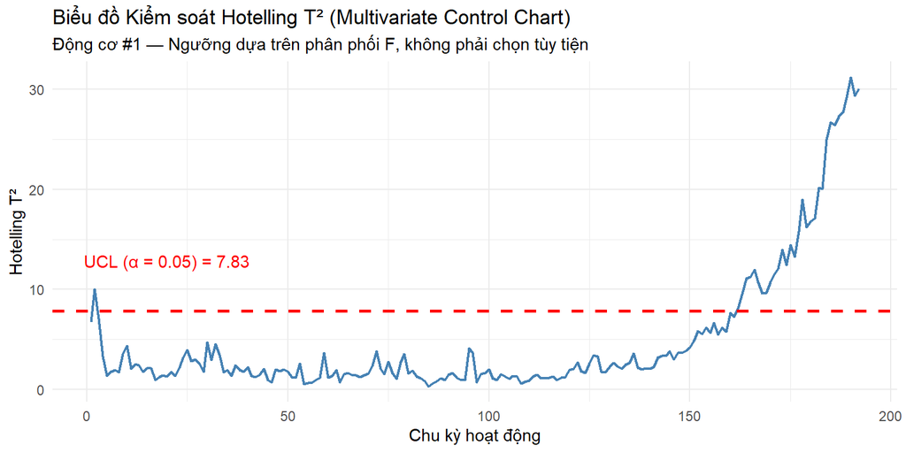

```r
p <- 3  # Số biến (PC1, PC2, PC3)
n_healthy <- nrow(healthy_data)

# Tính T² cho động cơ 1
engine1_pcs <- df_train %>% filter(engine_id == 1) %>% dplyr::select(PC1_KF, PC2, PC3)
T2 <- mahalanobis(engine1_pcs, center = healthy_mean, cov = healthy_cov)

# Ngưỡng UCL dựa trên phân phối F (mức ý nghĩa 5%)
alpha_test <- 0.05
UCL <- (p * (n_healthy + 1) * (n_healthy - 1)) /
       (n_healthy * (n_healthy - p)) * qf(1 - alpha_test, p, n_healthy - p)

df_t2 <- data.frame(Cycle = df_train %>% filter(engine_id == 1) %>% pull(cycle),
                     T2 = T2)

ggplot(df_t2, aes(x = Cycle, y = T2)) +
  geom_line(color = "steelblue", size = 0.8) +
  geom_hline(yintercept = UCL, linetype = "dashed", color = "red", size = 1) +
  annotate("text", x = 20, y = UCL + 5,
           label = paste0("UCL (α = 0.05) = ", round(UCL, 2)), color = "red") +
  theme_minimal() +
  labs(title = "Biểu đồ Kiểm soát Hotelling T² (Multivariate Control Chart)",
       subtitle = "Động cơ #1 — Ngưỡng dựa trên phân phối F, không phải chọn tùy tiện",
       x = "Chu kỳ hoạt động", y = "Hotelling T²")
```

```r
cat(sprintf("Ngưỡng UCL (alpha = 0.05): %.2f\n", UCL))
```

```
## Ngưỡng UCL (alpha = 0.05): 7.83
```

## 3.6 Phân tích Nhân tố Khám phá (EFA)

```r
cat("\n--- PHÂN TÍCH NHÂN TỐ KHÁM PHÁ (EFA) ---\n")
```

```
##
## --- PHÂN TÍCH NHÂN TỐ KHÁM PHÁ (EFA) ---
```

```r
efa_res <- fa(df_train_ma[, useful_sensors], nfactors = 2, rotate = "varimax", fm = "ml")
print(efa_res$loadings, cutoff = 0.3)
```

```
##
## Loadings:
##     ML2    ML1
## S2   0.931
## S3   0.900
## S4   0.967
## S7  -0.970
## S8   0.932
## S9          0.986
## S11  0.979
## S12 -0.977
## S13  0.933
## S14         0.996
## S15  0.947
## S17  0.915
## S20 -0.945
## S21 -0.943
##
##                   ML2   ML1
## SS loadings    10.740 2.253
## Proportion Var  0.767 0.161
## Cumulative Var  0.767 0.928
```

### 3.6.1 Phân tích Communality (Mức độ giải thích của Nhân tố chung)

Communality đo tỷ lệ phương sai của mỗi biến được giải thích bởi các nhân tố chung. Biến có communality > 0.5 được giải thích tốt.

```r
cat("Communality (Phần phương sai được giải thích bởi nhân tố chung):\n")
```

```
## Communality (Phần phương sai được giải thích bởi nhân tố chung):
```

```r
print(round(efa_res$communality, 3))
```

```
##    S2    S3    S4    S7    S8    S9   S11   S12   S13   S14   S15   S17   S20
## 0.878 0.843 0.945 0.941 0.948 0.990 0.962 0.955 0.949 0.992 0.911 0.872 0.905
##   S21
## 0.902
```

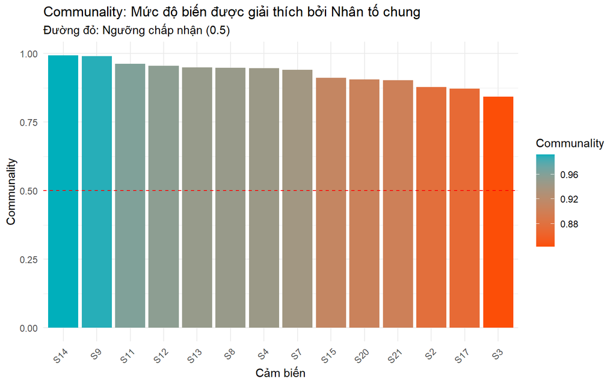

```r
comm_df <- data.frame(Sensor = names(efa_res$communality),
                      Communality = efa_res$communality)
ggplot(comm_df, aes(x = reorder(Sensor, -Communality), y = Communality, fill = Communality)) +
  geom_bar(stat = "identity") +
  geom_hline(yintercept = 0.5, linetype = "dashed", color = "red") +
  scale_fill_gradient(low = "#FC4E07", high = "#00AFBB") +
  theme_minimal() +
  labs(title = "Communality: Mức độ biến được giải thích bởi Nhân tố chung",
       subtitle = "Đường đỏ: Ngưỡng chấp nhận (0.5)",
       x = "Cảm biến", y = "Communality") +
  theme(axis.text.x = element_text(angle = 45, hjust = 1))
```

## 3.7 Phân cụm GMM và Phân tích Biệt thức

### 3.7.1 Đánh giá GMM bằng mclust (So sánh BIC)

```r
cat("\n--- ĐÁNH GIÁ GMM BẰNG TIÊU CHUẨN BIC ---\n")
```

```
##
## --- ĐÁNH GIÁ GMM BẰNG TIÊU CHUẨN BIC ---
```

```r
# GMM trên không gian PC1 (MA vs Kalman)
gmm_ma <- Mclust(df_train$PC1_MA, G = 3)
gmm_kf <- Mclust(df_train$PC1_KF, G = 3)

cat(sprintf("BIC của GMM trên 1 biến PC1 (MA): %.2f\n", max(gmm_ma$bic, na.rm=TRUE)))
```

```
## BIC của GMM trên 1 biến PC1 (MA): -105609.86
```

```r
cat(sprintf("BIC của GMM trên 1 biến PC1 (Kalman): %.2f\n", max(gmm_kf$bic, na.rm=TRUE)))
```

```
## BIC của GMM trên 1 biến PC1 (Kalman): -105010.27
```

### 3.7.2 Trực quan hóa 3 phân lớp suy thoái của GMM

Ta vẽ biểu đồ thể hiện sự suy thoái của Chỉ số Sức khỏe (PC1_KF) theo chu kỳ (Cycle), đồng thời tô màu 3 giai đoạn (Cụm) do GMM tự động học được.

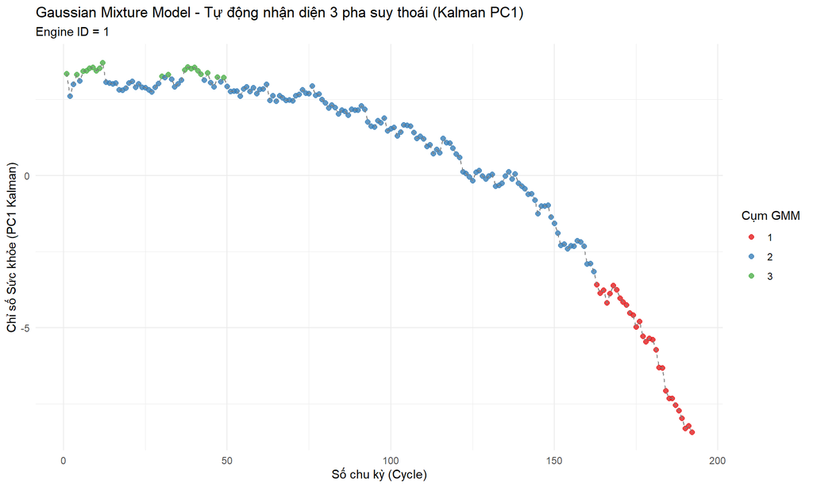

```r
# Lấy mẫu 1 động cơ để vẽ (Ví dụ engine_id = 1)
engine_sample <- df_train %>% filter(engine_id == 1)

# Do GMM label là 1, 2, 3 nhưng chưa chắc thứ tự đã theo độ hỏng,
# ta map màu trực tiếp từ classification
engine_sample$GMM_Class <- as.factor(gmm_kf$classification[df_train$engine_id == 1])

ggplot(engine_sample, aes(x = cycle, y = PC1_KF, color = GMM_Class)) +
  geom_point(size = 2, alpha = 0.8) +
  geom_line(color = "gray50", linetype = "dashed") +
  theme_minimal() +
  labs(title = "Gaussian Mixture Model - Tự động nhận diện 3 pha suy thoái (Kalman PC1)",
       subtitle = "Engine ID = 1",
       x = "Số chu kỳ (Cycle)",
       y = "Chỉ số Sức khỏe (PC1 Kalman)",
       color = "Cụm GMM") +
  scale_color_brewer(palette = "Set1")
```

> **Giải thích Thống kê học:** Bạn không thể so sánh trực tiếp BIC của không gian 14 chiều với BIC của không gian 1 chiều, do hàm log-likelihood (tích phân xác suất) nằm trong các thể tích không gian khác nhau. Sự so sánh khoa học nhất là so sánh chất lượng phân cụm của **GMM trên PC1_MA** và **GMM trên PC1_KF**. Với package `mclust`, BIC càng lớn càng tốt. Nếu BIC của Kalman cao hơn, chứng tỏ nó khử nhiễu ưu việt hơn, giúp dữ liệu tụ vào 3 cụm (Safe, Degradation, Critical) sắc nét hơn.

### 3.7.3 BIC Model Selection (Tìm số cụm tối ưu)

Cho `mclust` tự tìm số cụm tối ưu (G = 1..9) thay vì fix cứng G=3.

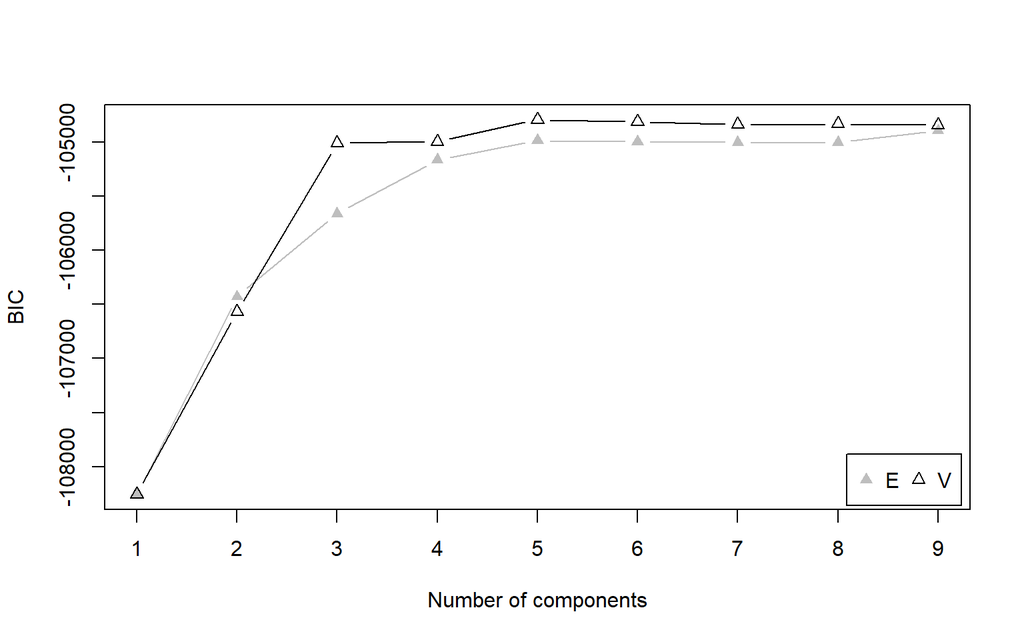

```r
gmm_bic <- mclustBIC(df_train$PC1_KF, G = 1:9)
plot(gmm_bic, main = "BIC Model Selection - Tìm số cụm tối ưu trên PC1 Kalman")
```

```r
summary(gmm_bic)
```

```
## Best BIC values:
##                V,5           V,6           V,8
## BIC      -104795.3 -104814.20030 -104832.75880
## BIC diff       0.0     -18.93862     -37.49712
```